# summary-spring-2018

Ben

4/4/2018

# Deriving efficient communication behavior in rational pragmatic agents

# Abstract

The combinatorial expressivity of natural language allows speakers to communicate about an unbounded set of potential meanings using a finite lexicon. But, by this same mechanism, a speaker may be confronted with multiple forms to express just a single meaning. How do speakers choose which form to use? Theories emphasizing communicative efficiency suggest rational speakers should attempt to optimize communicative properties of their utterances (Aylett & Turk, 2004; Levy & Jaeger, 2007; Genzel & Charniak, 2002). We evaluate the hypothesis that efficient production signatures arise from rational pragmatic agents and propose agent- and language-level features necessary to derive these signatures. We adopt a computational approach – simulating production behavior in pragmatic agents while manipulating agent- and language-level components of interest.

# Introduction

The combinatorial expressivity of natural language allows speakers to communicate about an unbounded set of potential meanings using a finite lexicon. But, by this same mechanism, a speaker may be confronted with multiple forms to express just a single meaning. At least two questions emerge from this observation: How do speakers choose which forms to use? And how does the accumulation of these choices give rise to statistical patterns found in natural language?

Evidence for these hypotheses have largely been taken from observational studies of naturalistic corpora, focusing on empirical measurements of “optimal” behavior at signature **linguistic choice-points**. While such evidence is compelling in its scope across levels of production, a question remains – why do speakers behave optimally?

We evaluate the hypothesis that efficient production signatures arise from rational pragmatic agents and describe the agent- and language-level features necessary to derive these signatures. We adopt a computational approach – simulating production behavior in pragmatic agents while manipulating agent- and language-level features.

# Optimal speaker production

### Introduction

To what extent is language organized around efficiency? Zipf’s (1939) observation that more frequently occuring words tend to have shorter forms served as the basis for perhaps the earliest analysis of languge design in terms of efficiency. Subsequent theories have extended this anlaysis showing that word length is better predicted by a word’s average predictability in context (Piantadosi, Tilly & Gibson, 2009). The link between communicative efficiency and linguistic form is now seen as a compelling source of explanation at multiple time-courses of speaker production.

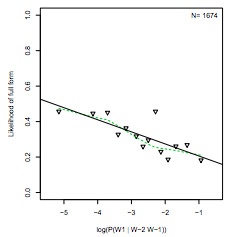

Levy & Jaeger (2007) fig. 1

- Choice point - syntax / relative clauses

If communication is optimal (efficient) then the most efficient way to send information is a constant rate.

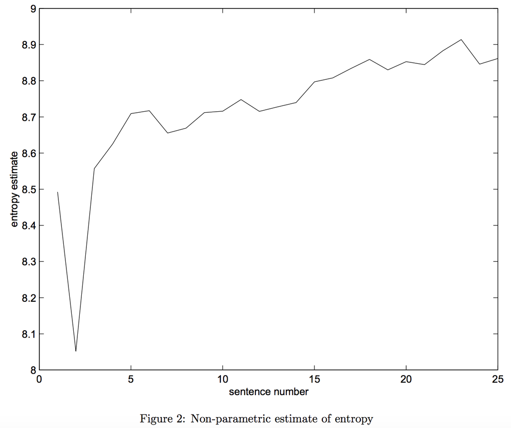

- Choice point - discourse

# Rational Speech-act Theory

## Basic model

A literal listener evaluates the truth-functional semantics of an utterance $u$ in proportion to the set of relevant utterances in the lexicon. Note that this base listener does not take the previous history of utterances $D$ into consideration.
$$L_0(m |u) \propto \delta(u)P(m)$$

The lowest level speaker chooses an utterance in proportion to the expected utility such that a listener will infer the correct intended meaning given that utterance.
$$S_n(u|m) \propto \exp(-\alpha(-log(L_{n-1}(m|u)) - cost(u)))$$

# Simulations

## UID-effects

### Model (Noisy RSA)

The literal listener evaluates an utterance with respect to their literal meanings $\delta(\cdot)$. Because noise $P_{noise}(\cdot)$ will sometimes corrupt the speakers utterances, the listener evaluates the likely intended utterance, inferred in the context of noise.
$$L_{0}(m|u_p) \propto P(m) \sum_{u_i}\delta(u_i, m)P_{\text{noise}}(u_i|u_p)$$

where $\delta(u_i, m) = True$ if $m \in [[u_i]]$.

Higher-order speakers choose utterances $u$ in accordance with their expected utility $\mathbb{U}(u;m)$ that a listener will recover the intended meaning $m$, while minimizing cost $cost(u)$.
$$S_n(u|m) \propto e^{\alpha\mathbb{U(u;m)}}$$
where the speaker is aware that noise may corrupt their intended utterance $u_i$ and the listener will need to recover that intended utterances from the produced utterance $u_p$.
$$\mathbb{U}(u;m) = \sum_{u_p}log(L_{n-1}(m|u_p))\times P_{\text{noise}}(u_p|u_i) - \text{cost}(u_i))$$
Higher-order listeners infer the intended meaning $m$ of an utterance $u$ by inferring the likely intended utterance $u_i$ given the possibility of noise.
$$L_{n}(m|u_p) \propto P(m) \sum_{u_i}S_{n}(u_i|m)P_{\text{noise}}(u_i|u_p)$$

### Results

#### Result 1: Speakers mark high-surprisal utterances

Speaker is more likely to use cue when the intended object is high surprisal.

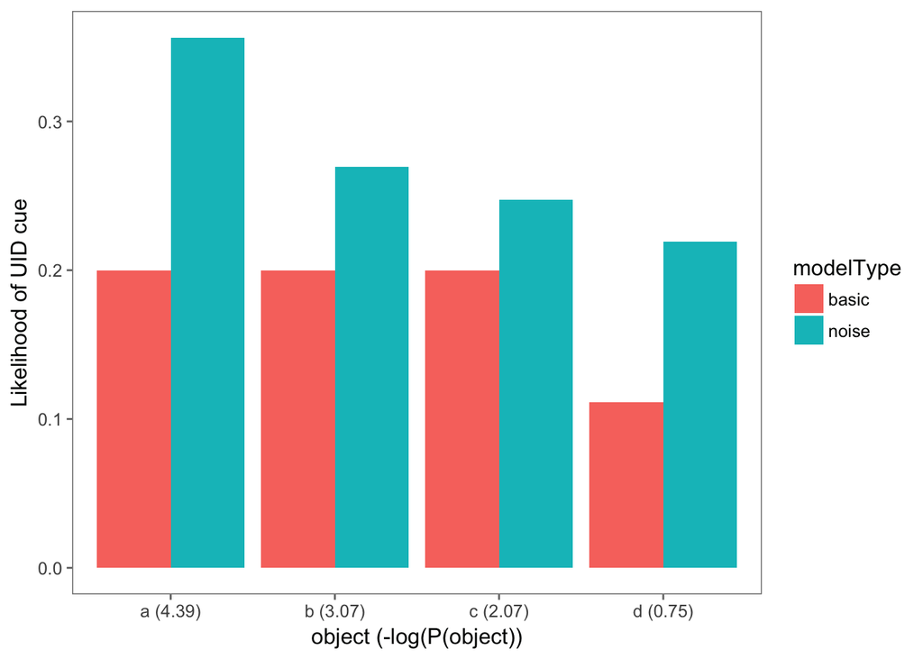

#### Result 2: Listener infer oncoming item is high-surprisal given cue

Listener is more likely to infer that oncoming material is high-surprisal given a cue.

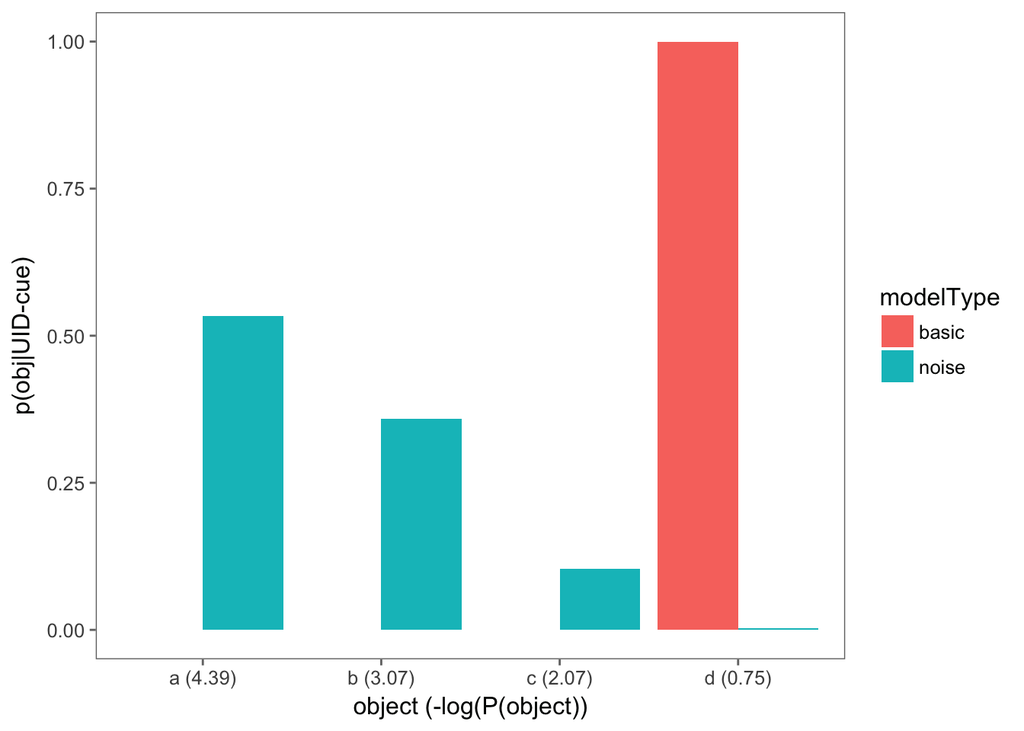

#### Result 3: Corpus analysis reflects UID relationship between likelihood to mark and surprisal

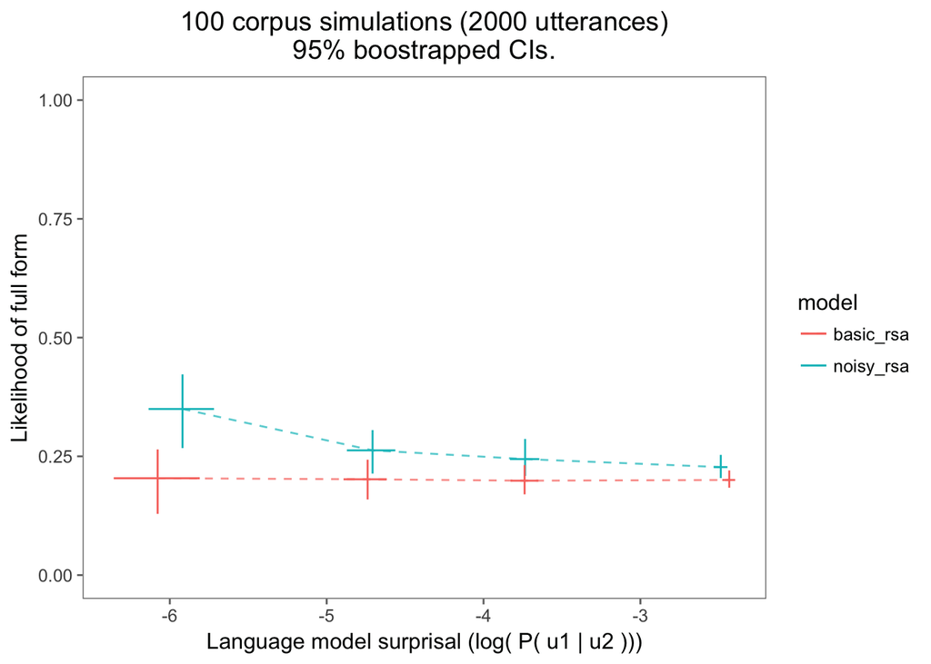

## CER-effects

- Unconditional entropy $H(X|L)$ should increase with sentence position.
- [SECONDARY MAYBE DON’T INCLUDE] $H(Y)$ remains constant over discourse.

### Model (Ambiguity+Topic RSA)

NOTE: Just refer to basic RSA model for low-level listener / speaker.

A literal listener evaluates the truth-functional semantics of an utterance $u$ in proportion to the set of relevant utterances in the lexicon. Note that this base listener does not take the previous history of utterances $D$ into consideration.
$$L_0(m |u) \propto \delta(u)P(m)$$

The lowest level speaker chooses an utterance in proportion to the expected utility such that a listener will infer the correct intended meaning given that utterance.
$$S_1(u|m) \propto \exp(-\alpha(-log(L_0(m|u)) - cost(u)))$$

Higher orders listeners jointly infer the meaning $m$ of the current utterance $u$ as well as the topic under discussion $T$ taking into account the complete discourse history $D$.
$$L_{1}(m, T|u, D) \propto S_1(u|m)P(m|T)P(T|D)$$
where the listener updates there posterior over topics given the complete history of utterances made by the speaker.
$$P(T|D) \propto P(T)\prod_{i}^{|D|}S_{n-1}(u_i|w_i)P(w_i|T)$$
Higher order speakers choose an utterance $u$ in accordance to the expected utility of using that utterance to convey a particular meaning $m$ within the context of a particular topic $T$ and the complete discourse history $D$.
$$S_{2}(u|w, T, D) \propto \mathbb{U}[u, T ;w, D]$$

$$\mathbb{U}[u, T;w, D] = \exp(-\alpha(log(L_2(m|u,T))P(T|D)-cost(u)))$$

### Results

#### Result 1: Listener gradually infers topic

Note (BP 20180408): Instead of binning within a run, why not calculate entropy between runs (so if we have 200 simulations check entropy of position 1.)

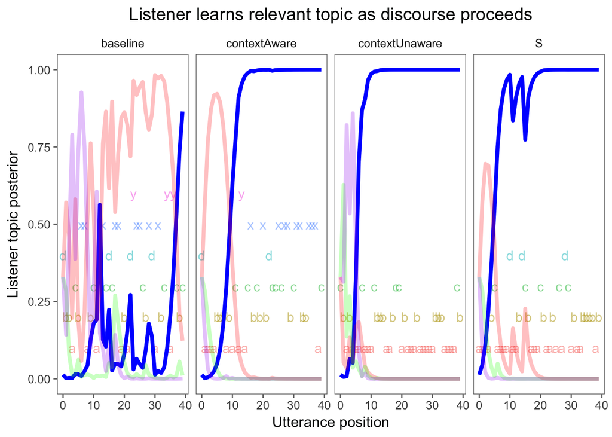

#### Result 2: Speaker more likley to use ambiguous utterance once listener is confident in topic

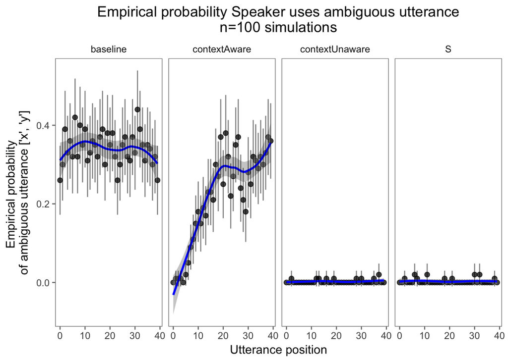

#### Result 3: Unconditional entropy effect

Resources:

- https://math.stackexchange.com/questions/2221096/can-conditional-entropy-hy-mid-x-be-expressed-by-kullback-leibler-divergence?utm_medium=organic&utm_source=google_rich_qa&utm_campaign=google_rich_qa
- https://ejde.math.txstate.edu/Volumes/2016/237/popescu.pdf
- https://en.wikipedia.org/wiki/Inequalities_in_information_theory#Lower_bounds_for_the_Kullback%E2%80%93Leibler_divergence
- https://en.wikipedia.org/wiki/Gibbs%27_inequality
- http://alumni.media.mit.edu/~bcroy/papers/bcroy_expected-entropy.pdf

See Genzel & Charniak (2002) footnote 2. More specifically, what they’re looking for is the cross entropy between all words at position $i$ and the true model of English to be the same for all $i$.

$$H_{cross}(X^{(i)}, C) = K = H(X^{(i)}) + D_{KL}(X^{(i)}||C)$$

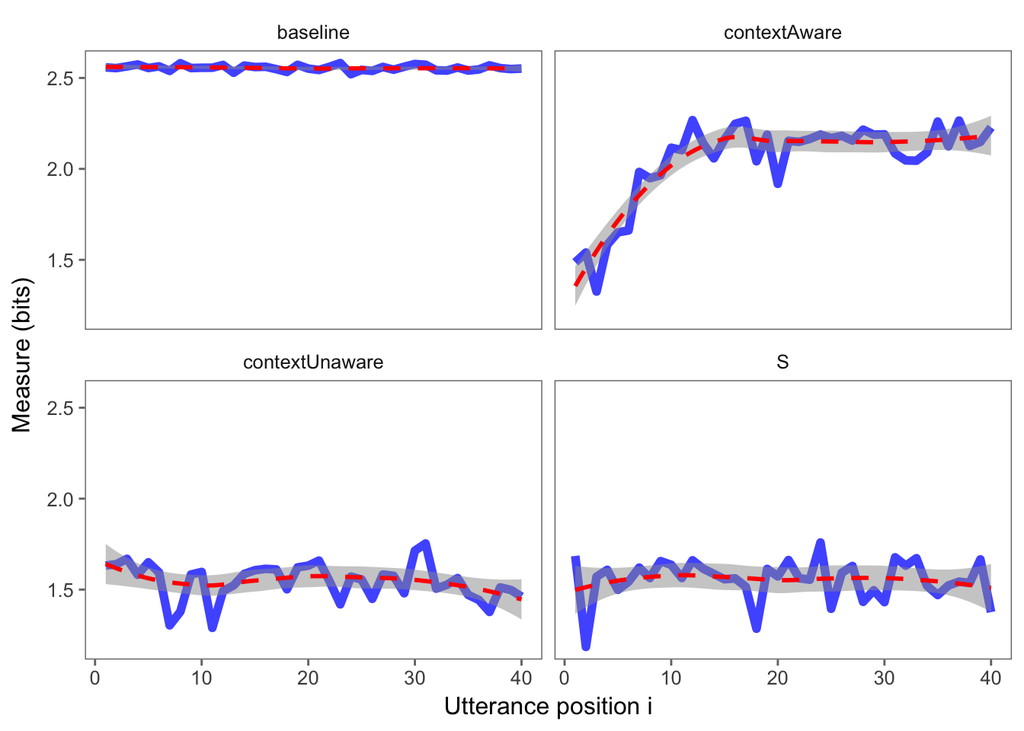

## Combined model

### Model (Ambiguity+Topic Noisy RSA)

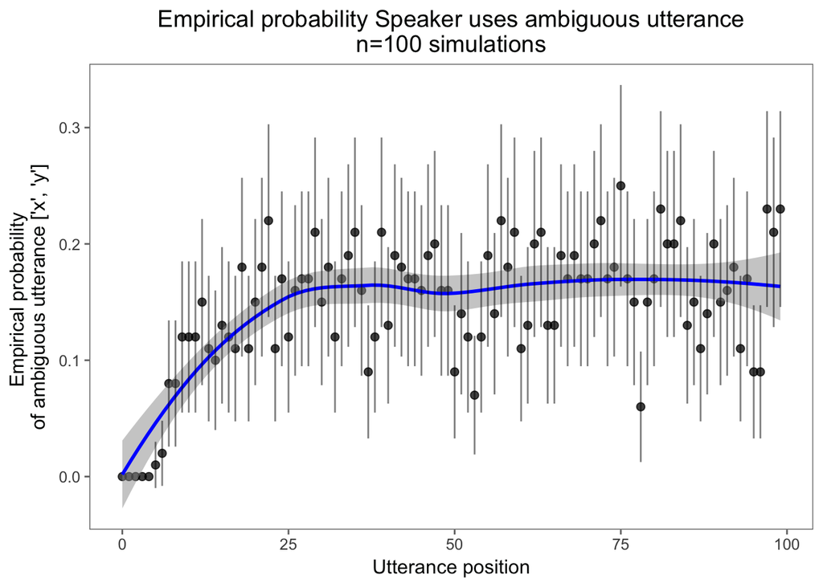

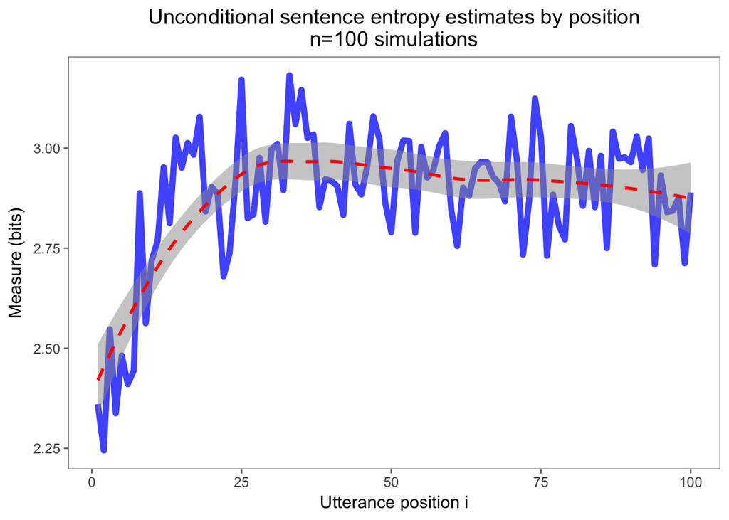

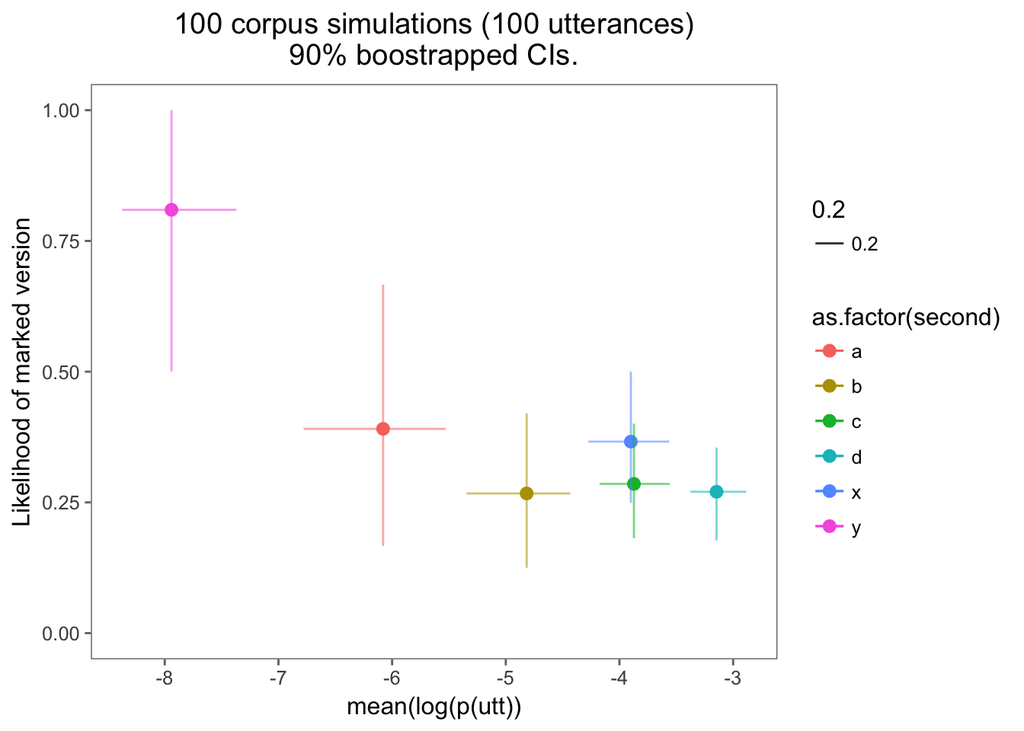

```r
full_sims_lm %>%
  ggplot(aes(x=avgPostProb, y=avgLikelihood, col=as.factor(second))) +
    geom_point(size=2.5) +
    geom_errorbar(aes(ymax=ymax, ymin=ymin, alpha=0.2), width=0) +
    geom_errorbarh(aes(xmax=xmax, xmin=xmin, alpha=0.2), height=0) +
    ylab('Likelihood of marked version') +
    xlab('mean(log(p(utt))') +
    ylim(0, 1) +
    ggtitle(paste0(nSims, " corpus simulations (", nUtterances, " utterances)", "\n90% boostrapped CIs.")) +
    theme_few() +
    theme(plot.title=element_text(hjust = 0.5))
```

## Results

```r
kable(df_table)
```

| behavior | reference | base model | rsa + noise | rsa + ambiguity | rsa + noise + ambiguity |
| --- | --- | --- | --- | --- | --- |
| Basic scalar implicature | Frank & Goodman (2012) | X | X | X | X |
| Speaker mark high-suprisal content | Levy & Jaeger (2007), Jaeger (2010) |  | X |  | X |
| Listener um-implicature | Levy & Jaeger (2007), Jaeger (2010) |  | X |  | X |
| Corpus UID effect | Levy & Jaeger (2007), Jaeger (2010) |  | X |  | X |
| Increase use of ambiguous utterances when context disambiguates | Piantadosi (2012) |  |  | X | X |
| Increase unconditional entropy over discourse | Genzel & Charniak (2002) |  |  | X | X |